# SEB: Task for Junior Quantitative Analyst in Credit Risk Model Validation

Livija Vasiliauskaite

2026-01-27

### Data Pre-processing Steps

Before further analysis, the following data pre-processing steps were taken:

- Fixed *IP_ID* formatting mismatch in *dat_obligor* data set. Some ID’s appeared with a dash (i.e., DVO_426 instead of DVO426), which was removed.
- Removed most incomplete duplicate rows from *dat_arrangement* (i.e., row with most NA’s was removed)
- Data sets containing portfolio details (*dat_obligor*, *dat_arrangement*, *dat_scoring*) were joined taking *dat_scoring* as the base one, since the data set was most complete
- Fixed data types of the following variables according to the description given: *PD_POOL* as factor, *AR_ID* as character, *EDUCATION* as factor
- Several observations with abnormally highly *DPD* (number of past due days during last 24 months) were observed. Values exceeding 730 (max days per 24 months) were replaced by NA’s to reflect possible recording/calculation error. Important note: later in the analysis this variable is capped at a pre-specified value given in the task, this is not changed.
- *Most notably*, for the portfolio summary and model/estimate evaluation, a new portfolio subset, defined as the “at-risk” set, was created by removing subsequent YEAR–AR_ID pairs once an arrangement is marked as having defaulted within the next 12 months. The rationale behind this approach is that, since the data are reported at year-end, a deal marked as defaulting within 12 months should already be considered defaulted in the following year. If this assumption holds, including arrangements that have already defaulted in the dataset could be misleading, as the goal is to predict defaults and assess overall portfolio risk. Keeping already-defaulted deals could distort portfolio statistics and model evaluation by inflating the number of defaults. The newly defined “at-risk” set is used as the primary dataset for further analysis unless stated otherwise.

### Task: Provide opinion on data quality in terms of completeness, accuracy, consistency.

As briefly mentioned in the previous section, the provided data sets exhibit several issues commonly observed in financial data, where variables are collected from multiple sources and at different points in time. These include inconsistencies in obligor identifier formatting, unrealistically high values of *DPD*, duplicate rows, and several hundred arrangements appearing in the scoring data set but not in the arrangement-level data. These issues were addressed during data pre-processing.

Moreover, the forward-looking default flags seems to be inconsistent: for some agreements the future default is marked for one year but not for the subsequent ones. This could be caused by overlap or delay in reporting. However, the number of such observations is low (approx. 195).

A more significant issue relates to data completeness. Approximately 22% of all data cells contain missing values in the original full portfolio set. Missingness is highly concentrated in two variables: *DPD* and *M_LAST_DPD*, for which around 88% of observations are missing.

Thus, while data is reasonably accurate and consistent after pre-processing, high number of missing values in the main risk attributes raises significant issues when evaluating portfolio performance.

[1] 0 [1] 0

Percentage of Missing Values by Variable

|  | variable | Missing_perc |
| --- | --- | --- |
| DPD_capped | DPD_capped | 87.74 |
| DPD | DPD | 87.72 |
| M_LAST_DPD | M_LAST_DPD | 87.72 |
| DEBT_RATIO | DEBT_RATIO | 6.11 |
| PD | PD | 2.49 |
| PD_POOL | PD_POOL | 2.49 |
| EDUCATION | EDUCATION | 2.48 |
| AGE | AGE | 2.02 |
| YEAR | YEAR | 0.00 |
| IP_ID | IP_ID | 0.00 |
| AR_ID | AR_ID | 0.00 |
| DFLT_FLAG | DFLT_FLAG | 0.00 |
| TRUE_D | TRUE_D | 0.00 |

[1] 21.44295

### Task: Visualize and provide a brief description on qualitative portfolio structure in terms of obligor, arrangement and scoring features available, portfolio composition and performance. Assess consistency over time

#### Overall statistics

The below table provides an initial overview of the “at risk” portfolio across the observed years. The number of arrangements and obligors remains broadly stable over time. More relevantly, the number of arrangements defaulting within the future 12 months (a forward-looking default indicator) varies substantially across years.

Overall, the proportion of defaulting arrangements in the portfolio is relatively small compared to non-defaulting ones, which is relevant for model evaluation, as it implies class imbalance.

Portfolio summary per year

| Year | Number of Arrangements | Number of Obligors | Number of Defaults | Default Rate |
| --- | --- | --- | --- | --- |
| 2022 | 12000 | 10524 | 1528 | 0.127 |
| 2023 | 10789 | 9552 | 407 | 0.038 |
| 2024 | 10731 | 9510 | 3015 | 0.281 |
| Total | 33520 | 14000 | 4950 | 0.148 |

#### Descriptive statistics of risk drivers and scoring

The distribution of numerical risk drivers and portfolio characteristics is summarized in the below descriptive statistics table and further visualized using yearly histograms.

Numeric portfolio summary per year

| YEAR | Variable | N | Mean | SD | Min | Q1 | Median | Q3 | Max |
| --- | --- | --- | --- | --- | --- | --- | --- | --- | --- |
| 2022 | AGE | 11782 | 50.71 | 14.94 | 18.00 | 39.00 | 51.00 | 63.00 | 75 |
| 2023 | AGE | 10573 | 51.27 | 14.91 | 18.00 | 39.00 | 52.00 | 64.00 | 76 |
| 2024 | AGE | 10496 | 51.92 | 14.89 | 18.00 | 40.00 | 52.00 | 64.00 | 77 |
| 2022 | DEBT_RATIO | 11281 | 0.40 | 0.32 | 0.01 | 0.12 | 0.26 | 0.68 | 1 |
| 2023 | DEBT_RATIO | 10103 | 0.36 | 0.32 | 0.00 | 0.09 | 0.23 | 0.65 | 1 |
| 2024 | DEBT_RATIO | 10081 | 0.33 | 0.32 | 0.00 | 0.06 | 0.20 | 0.62 | 1 |
| 2022 | DPD_capped | 1151 | 31.25 | 76.90 | 1.00 | 1.00 | 2.00 | 17.00 | 652 |
| 2023 | DPD_capped | 237 | 29.13 | 81.30 | 1.00 | 1.00 | 1.00 | 15.00 | 621 |
| 2024 | DPD_capped | 1230 | 33.19 | 82.92 | 1.00 | 1.00 | 3.00 | 25.75 | 683 |
| 2022 | M_LAST_DPD | 1154 | 6.95 | 2.60 | 0.00 | 5.00 | 7.00 | 9.00 | 19 |
| 2023 | M_LAST_DPD | 237 | 6.62 | 2.54 | 0.00 | 5.00 | 7.00 | 8.00 | 15 |
| 2024 | M_LAST_DPD | 1235 | 6.93 | 2.42 | 0.00 | 5.00 | 7.00 | 9.00 | 15 |
| 2022 | PD | 11714 | 0.08 | 0.25 | 0.00 | 0.00 | 0.00 | 0.00 | 1 |
| 2023 | PD | 10511 | 0.04 | 0.17 | 0.00 | 0.00 | 0.00 | 0.01 | 1 |
| 2024 | PD | 10451 | 0.16 | 0.36 | 0.00 | 0.00 | 0.00 | 0.01 | 1 |

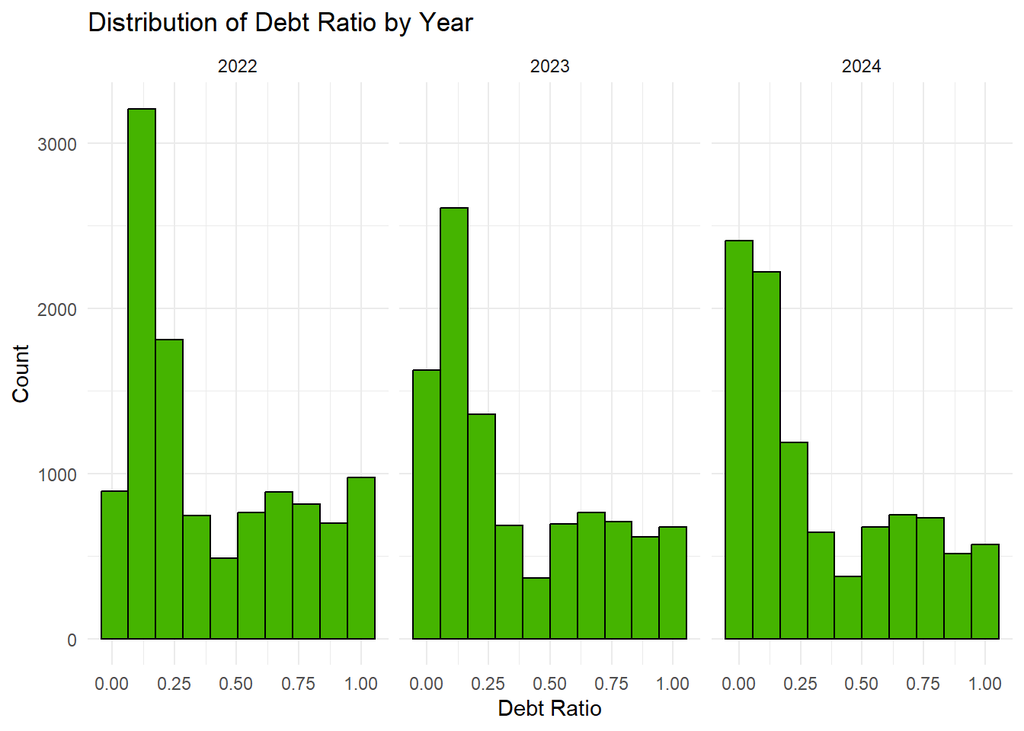

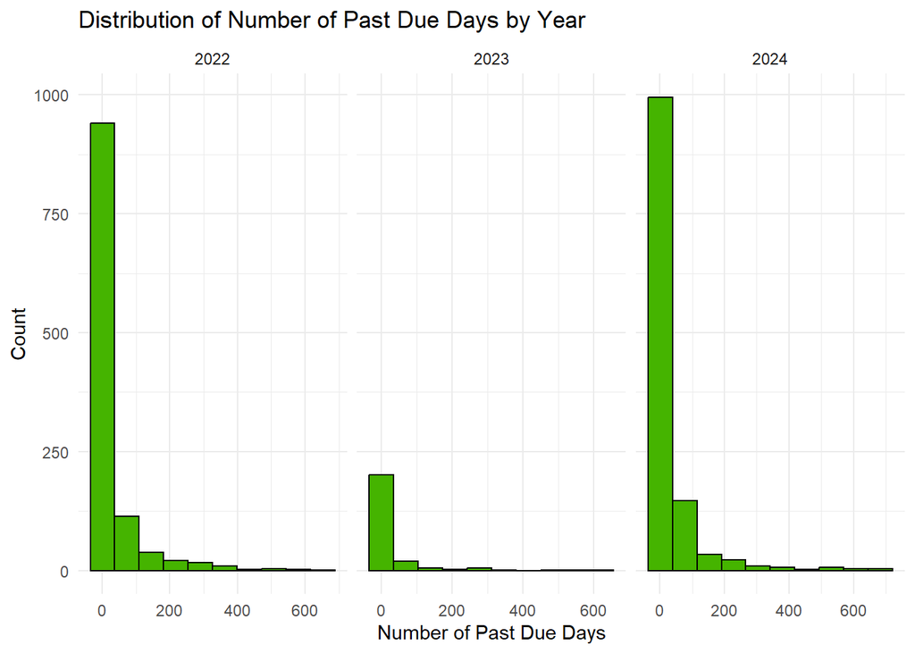

For the number of months since the last past due event, the distribution is centered around 7 months, with no pronounced skewness and relatively stable summary statistics across years, though, as mentioned before, fewer observations are available for 2023. Overall, past due days for the portfolio appear to be few and far between.

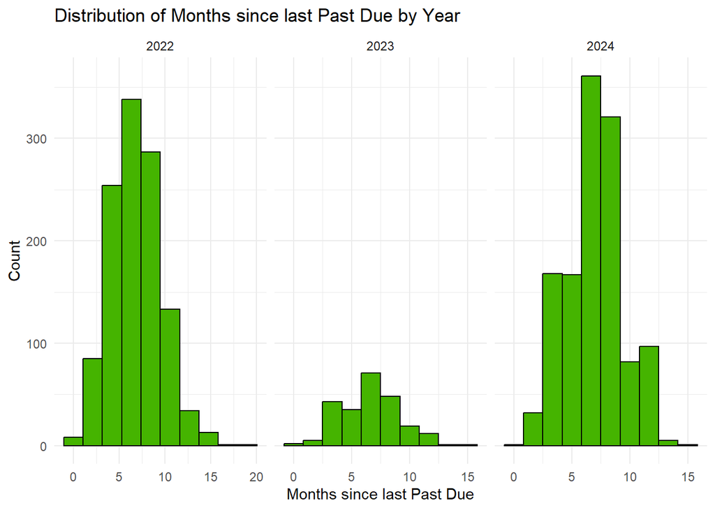

#### Obligor Characteristics

It it important to note that these statistics are calculated at the arrangement level rather than the obligor level, thus the obligors with multiple arrangements contribute proportionally more observations. This approach is chosen to reflect age as the potential risk drivers at arrangement level and subsequently how exposed to such risk is the porfolio.

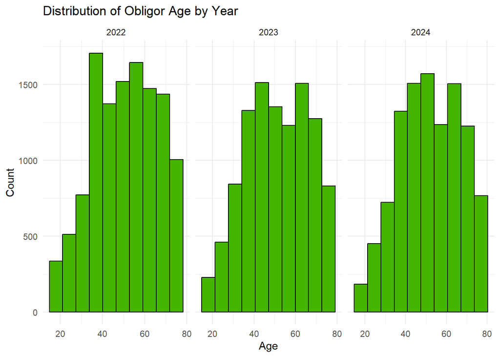

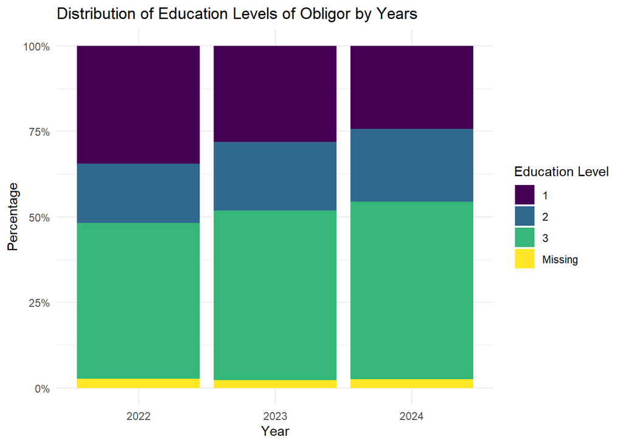

#### Model-Based Risk Measures

The estimated probability of default distribution is highly skewed, with most arrangements assigned extremely low PD values (close to zero), while a smaller subset exhibits values close to one. The distribution appears bimodal, suggesting that either medium-risk arrangements are rare in the portfolio or that the model does not sufficiently differentiate intermediate risk levels. This will is discussed in more detail in the model evaluation section.

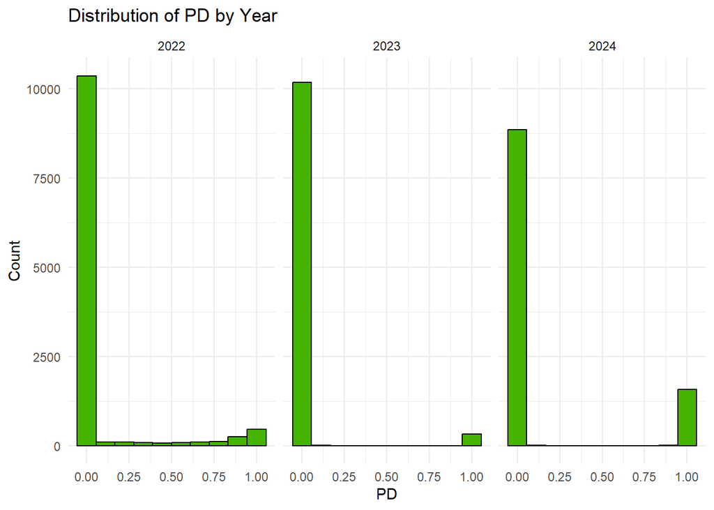

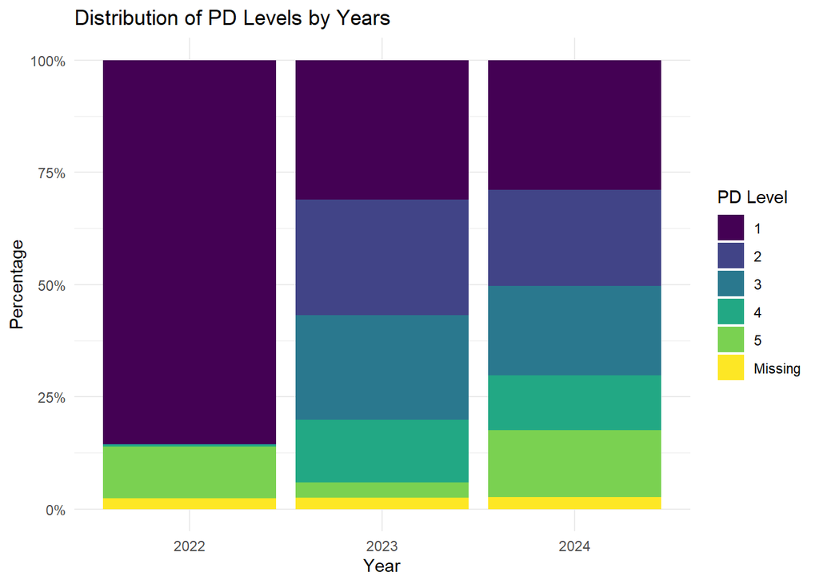

#### Summary

As the first look at the portfolio data, the descriptive statistics suggest that the portfolio is not inherently high-risk. Arrangement holders are mostly middle-aged, on average educational level is relatively high, debt ratios are moderate, and past-due events are not frequent. This is further supported by the relatively low proportion of arrangements defaulting within the forward-looking 12-months.

#### Relationship Between Risk Drivers and Default Status

Finally, to glimpse at the possible relationship between risk drivers and future default status, boxplots displaying distribution of the risk characteristics by default future default status (1 if defaults within next 12 months and 0 if does not) are presented below.

- Obligor age does not show meaningful differences between defaulting and non-defaulting arrangements.
- Debt ratio exhibits slightly higher distributions for defaulting arrangements in 2022 and 2023, suggesting a potential relationship with default risk.
- Days past due shows a clearly more right-skewed distribution for defaulting arrangements, including extreme values.
- Months since last past due shows higher values for non-defaulting arrangements in 2022. Unfortunately we do not have enough data to meaninfully compare the distributions for the other years.

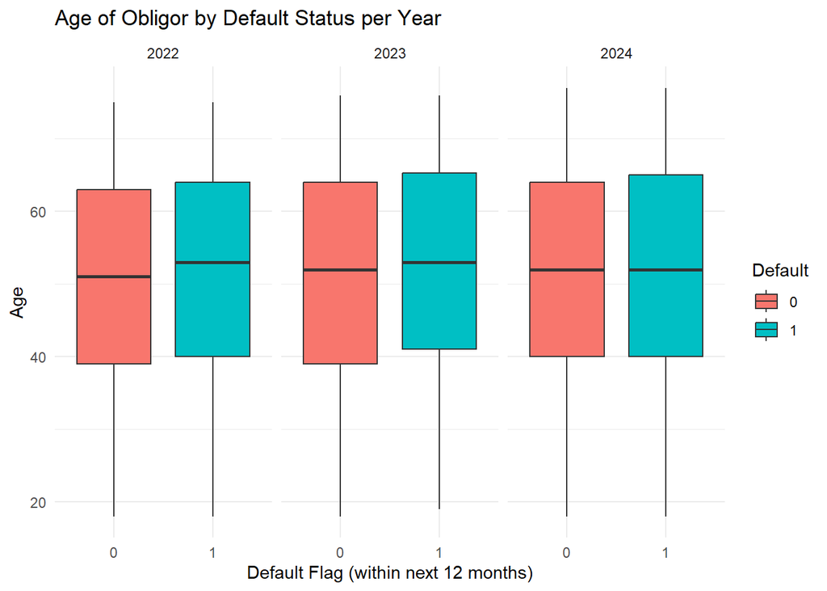

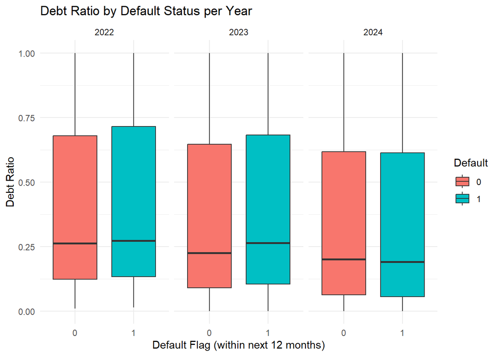

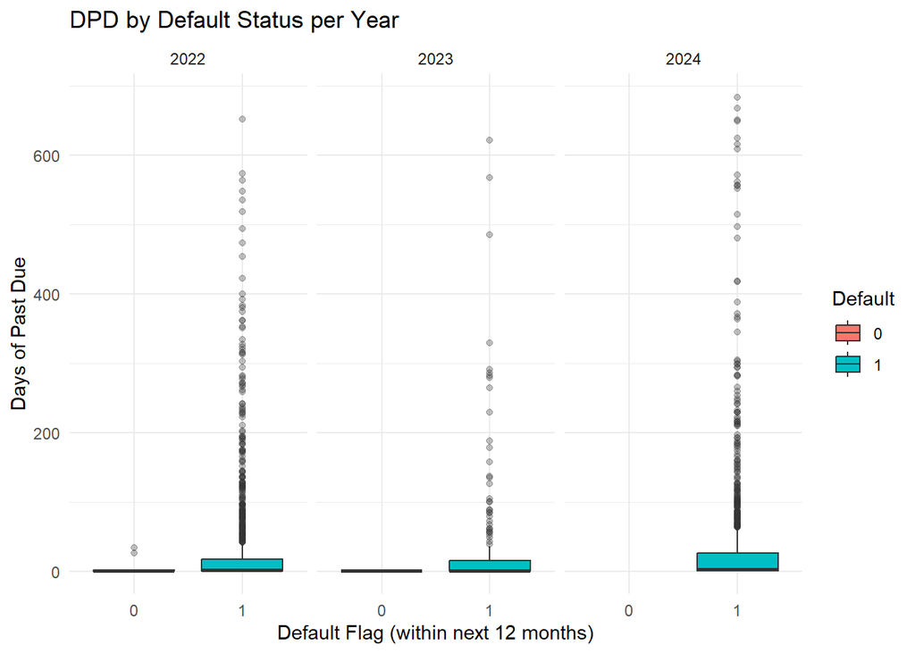

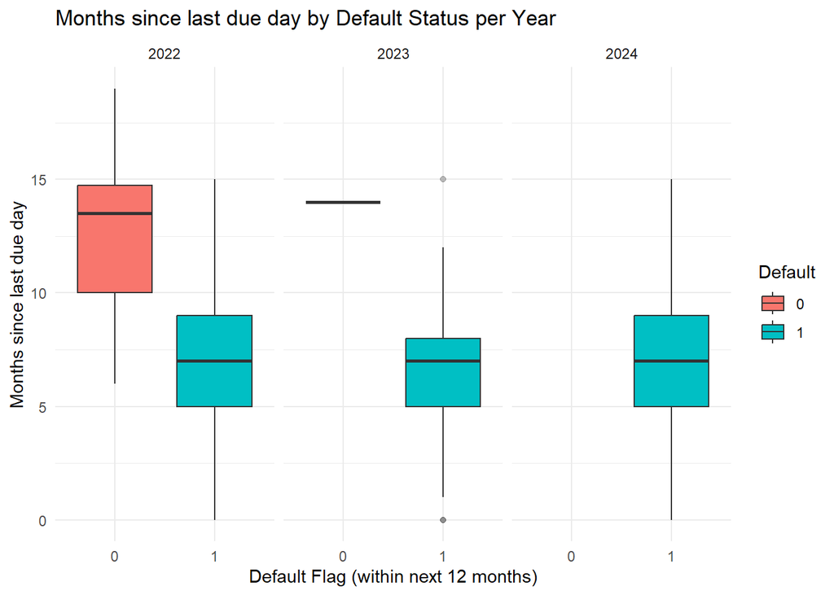

### Task: Assess correctness of PD estimate calculation.

I interpreted this task as checking whether the provided PD estimates are consistent with the model and data.

The performance of the model, i.e., whether the predictions correspond to the observed data will be checked in the next section.

First, basic sanity checks are performed to evaluate whether the estimates are within the appropriate range [0,1]. Further, PD pool assignment checked, whether is its consistent with the definition provided in the task and if all observations fall into one pool.

No issues were found.

```
## # A tibble: 5 × 3
##   PD_POOL min_PD max_PD
##   <ord>    <dbl>  <dbl>
## 1 1       0      0.0008
## 2 2       0.0008 0.003
## 3 3       0.003  0.009
## 4 4       0.009  0.0477
## 5 5       0.0481 1
```

Moreover, probability of default estimates were re-calculated using provided model coefficients and at risk portfolio data. Data was prepared as per provided description:

- Obligor level maximum number of past due days and minimum number of months since last due were calculated
- Education levels were dummy encoded
- NA’s were replaced by given values
- Flooring, capping and scaling for numeric variables was conducted

The re-estimated probabilities of default were then compared to the provided estimates.

Around 10% of the observations in the at risk set has large PD estimation mismatch, i.e., the difference of more than 0.9 in absolute value. Since quick manual re-calculation as a check yielded the same results as the re-calculated estimates, we can assume this mismatch is likely caused by data inconsistencies or missing value replacement. For example, in case where new estimates predict large PD while the given ones - negligible probability of default, the difference might be influenced by missing values in maximum past due days being replaced by 400 - which is a large value that is likely predicting a default.

```
##     Min.  1st Qu.   Median     Mean  3rd Qu.     Max.     NA's
## -1.00000 -0.00497 -0.00058 -0.09109 -0.00008  0.99954      844
```

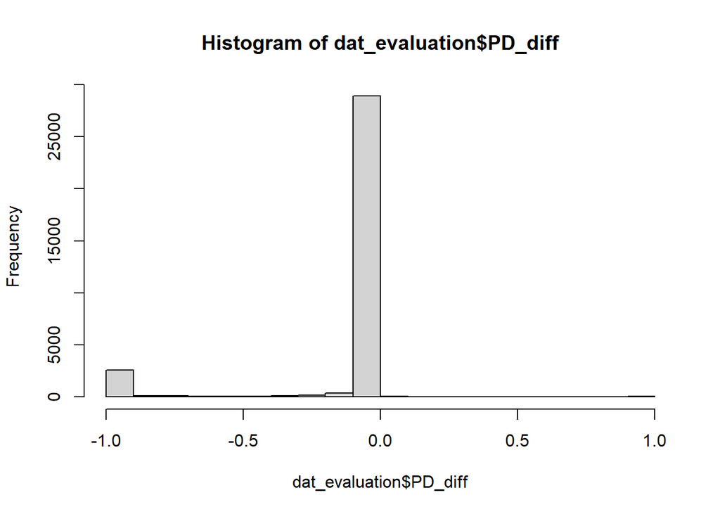

### Model evaluation

The first look into the models performance is provided by the below table reporting the average predicted probability of default (PD) by realized default status. Defaulting arrangements exhibit higher predicted PDs compared to non-defaulting ones, indicating that the model assigns higher risk estimates to arrangements that default in the future. Therefore, model differentiates risk at the aggregate level.

```
## # A tibble: 2 × 2
##   DFLT_FLAG mean_pd
##       <int>   <dbl>
## 1         0 0.00295
## 2         1 0.597
```

Further analysis of the distribution of predicted probabilities of default by realized future default status reveals notable misclassifications. For non-defaulting arrangements, the predicted PDs are largely concentrated near zero, indicating accurate risk assessments. However, for defaulting arrangements, a substantial proportion of predicted PDs are also near zero, that is, model assigns very low default probability to arrangemnets that subsequently default.

Given that correctly predicting defaults is the primary objective, the model demonstrates limited risk differentiation for defaulting arrangements. This is perhaps not surprising, considering the high proportion of non-defaulting arrangements in the portfolio, which likely results in the model being trained on relatively few default cases.

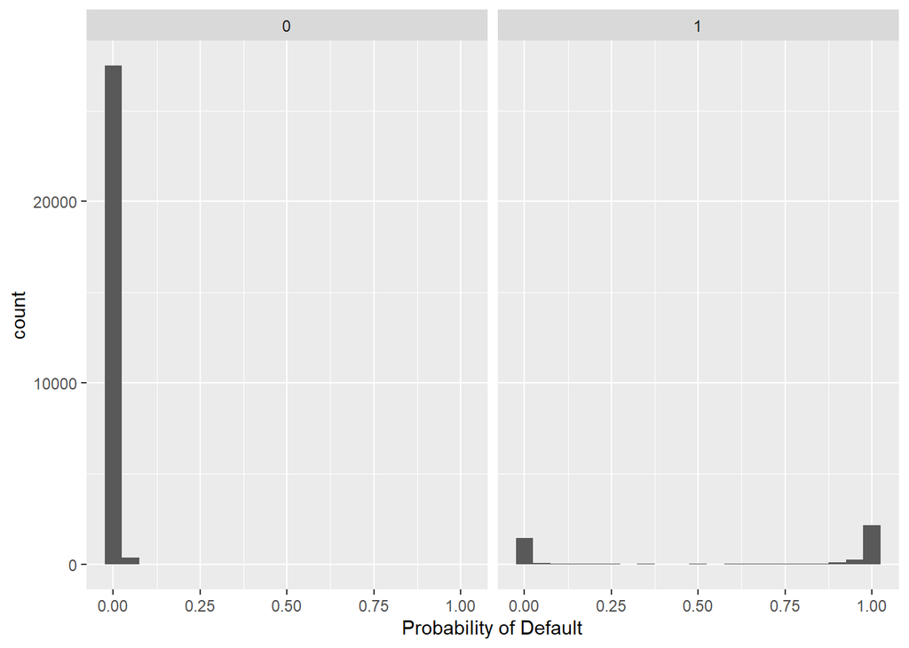

Calibration plot further depicts that model fails to differentiate risk well for mid-range PD’s and underestimates risk for these segments, as indicated by high observed default rate for the mid-range PD bins.

[figure not shown]

Similar conclusions can be drawn from the ROC plot. The model performs well for extreme risk levels: many defaults are identified with few false positives. However, for the moderate-risk arrangements, the model is not as good in differentiating, as indicated by the shallow slope in the mid-range of false positive rate. Some defaults are only captured when allowing a high false positive rate.

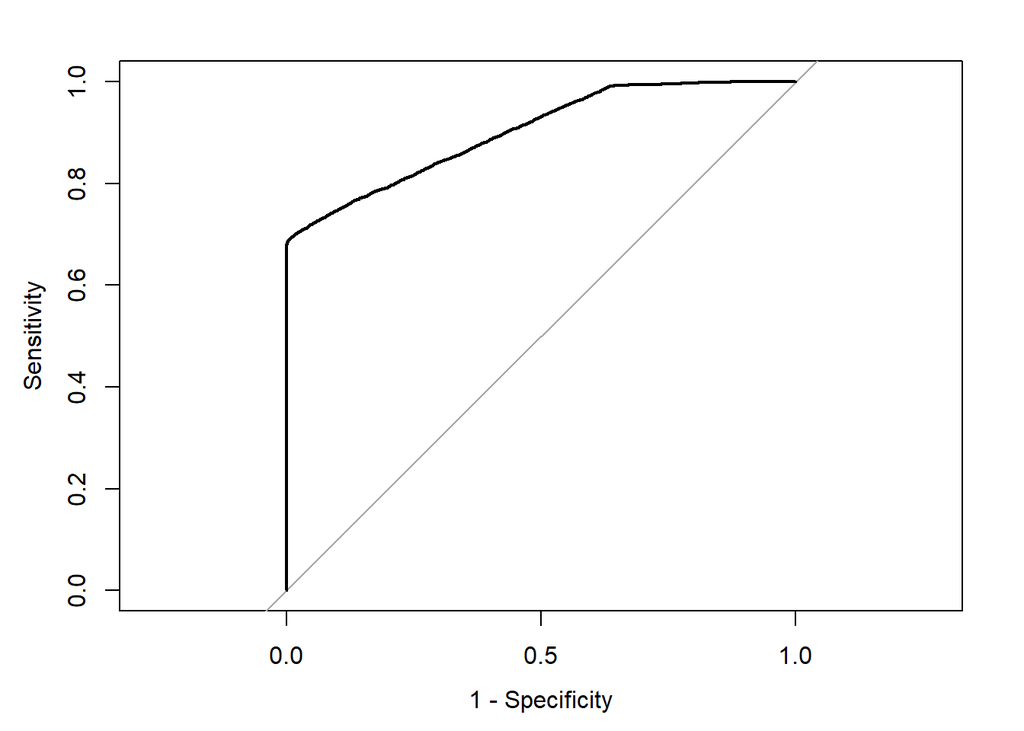

Lastly, AUC are calculated. High AUC value indicates that extreme cases are predicted well.

```r
auc(rocCurve)
```

```
## Area under the curve: 0.9013
```

# Appendix: R Code

```r
#libraries
library(dplyr)
library(knitr)
library(kableExtra)
library(tidyverse)
library(forcats)
library(ggplot2)
library(pROC)
library(fastDummies)

# Reading data -------

dat_arrangement <- read.csv("dat_arrangement.csv", na.strings = c("#NA", "NA"))
dat_obligor <- read.csv("dat_obligor.csv", na.strings = c("#NA", "NA"))
dat_scoring <- read.csv("dat_scoring.csv", na.strings = c("#NA", "NA"))
par_model <- read.csv("par_model.csv", na.strings = c("#NA", "NA"))
par_pools <- read.csv("par_pools.csv", na.strings = c("#NA", "NA"))

##############
# Data pre-processing
##############

# IP_ID missing in scoring data set:
missing_IP <- dat_obligor %>%
  distinct(IP_ID) %>%
  anti_join(dat_scoring %>% distinct(IP_ID), by = "IP_ID")

# Fixing IP_ID coding:
dat_obligor_fix <- dat_obligor %>%
  mutate(IP_ID = str_replace_all(IP_ID, "_", ""))

length(unique(dat_obligor_fix$IP_ID)) # 14000 - same

#Checking after cleaning:
missing_IP <- dat_obligor_fix %>%
  distinct(IP_ID) %>%
  anti_join(dat_scoring %>% distinct(IP_ID), by = "IP_ID") #none now, both ways

# Arrangement ID's, missing in Arrangement data set:

missing_AR <- dat_scoring %>%
  distinct(AR_ID, YEAR) %>%
  anti_join(dat_arrangement %>% distinct(AR_ID, YEAR), by = c("AR_ID", "YEAR"))

# Checking if any year-ID is missing from scoring data (other way around)
missing_AR <- dat_arrangement %>%
  distinct(AR_ID, YEAR) %>%
  anti_join(dat_scoring %>% distinct(AR_ID, YEAR), by = c("AR_ID", "YEAR"))
# None
missing_IP <- dat_obligor_fix %>%
  distinct(IP_ID, YEAR) %>%
  anti_join(dat_scoring %>% distinct(IP_ID, YEAR), by = c("IP_ID", "YEAR"))
#OK

# Checking for duplicates
dup <- dat_arrangement %>%
  count(AR_ID, YEAR) %>%
  filter(n > 1)

dat_obligor_fix %>%
  count(IP_ID, YEAR) %>%
  filter(n > 1)
#None

dat_scoring %>%
  count(AR_ID, YEAR) %>%
  filter(n > 1)
#None

# Removing incomplete (most NA's) duplicate row:
dat_arrangement_fix <- dat_arrangement %>%
  group_by(AR_ID, YEAR) %>%
  arrange(rowSums(is.na(across(everything())))) %>%
  slice(1) %>%
  ungroup()

# Joining data sets
dat_portfolio <- dat_scoring %>%
  left_join(dat_obligor_fix, by = c("IP_ID", "YEAR")) %>%
  left_join(dat_arrangement_fix, by = c("AR_ID", "YEAR"))

#Checks:

#No. rows match with the most complete dataset
nrow(dat_portfolio) == nrow(dat_scoring) #TRUE

# Duplicate keys
dat_portfolio %>%
  count(AR_ID, YEAR) %>%
  filter(n > 1)
# None

# Fixing data types
dat_portfolio <- dat_portfolio %>%
  mutate(AR_ID = as.character(AR_ID),
         PD_POOL = factor(PD_POOL, levels = 1:5, ordered = TRUE),
         TRUE_D = factor(DFLT_FLAG), # introduced to not overwrite numeric DFLT_FLAG
         EDUCATION = factor(EDUCATION, levels = 1:3, ordered = TRUE))


# Quick summary to check possible odd values or ranges, outliers.
summary(dat_portfolio)

# Replacing the abnormal values with NA's
dat_portfolio <- dat_portfolio %>%
  mutate(DPD_capped = ifelse(DPD > 730, NA, DPD)) #rough calculation 365*2

# Checking missing values --------
# For character variables, checking is any strage/empty strings are present (as NA's)
missing_val <- c("N/A", "#NA", "##NA", "", "MISSING_VALUE", " ")
sum(dat_portfolio$IP_ID %in% missing_val, na.rm = TRUE)
sum(dat_portfolio$AR_ID %in% missing_val, na.rm = TRUE)

# Percentage of missing values per column/variable
NA_perc <- sapply(dat_portfolio, function(x) sum(is.na(x)) * 100 / length(x))
sort(NA_perc, decreasing = TRUE)

# total percentage of NA's
(sum(is.na(dat_portfolio)) / (nrow(dat_portfolio) * ncol(dat_portfolio))) * 100

# Inconsistencies in Default flag: -----
# E.g., for RTD964 - 2023 marked as default, but not 2024
dat_portfolio %>%
  arrange(AR_ID, YEAR) %>%
  group_by(AR_ID) %>%
  mutate(DFLT_NEXT_Y = lead(DFLT_FLAG)) %>%
  ungroup() %>%
  count(DFLT_FLAG, DFLT_NEXT_Y)

# 195 obs. has 1 previous year and 0 next year (accounting time error?)

# Creating at risk data set ---------
# Marking which year the deal first has reported (future) default (if any)
# and removing subsequent years if marked as defaulted within 12 future months
dat_risk <- dat_portfolio %>%
  group_by(AR_ID) %>%
  mutate(FIRST_DFLT_YEAR = ifelse(
      any(DFLT_FLAG == 1, na.rm = TRUE),
      min(YEAR[DFLT_FLAG == 1], na.rm = TRUE),NA)) %>%
  ungroup() %>%
  filter(is.na(FIRST_DFLT_YEAR) | YEAR <= FIRST_DFLT_YEAR)

##############
# Descriptive statistics
##############
# Summmary tables ------

# Portfolio summary - at risk data set

portfolio_summary <- dat_risk %>%
  group_by(YEAR) %>%
  summarise(n_arrangements = n_distinct(AR_ID),
    n_obligors = n_distinct(IP_ID),
    n_defaults = sum(DFLT_FLAG == 1, na.rm = TRUE),
    default_rate = mean(DFLT_FLAG == 1, na.rm = TRUE)) %>%
  arrange(YEAR)


# Adding total row for all years
portfolio_summary_total <- portfolio_summary %>%
  summarise(YEAR = "Total",
    n_arrangements = sum(n_arrangements),
    n_obligors = n_distinct(dat_risk$IP_ID),
    n_defaults = sum(n_defaults),
    default_rate = n_defaults / n_arrangements)

portfolio_summary_final <- bind_rows(portfolio_summary %>% mutate(YEAR = as.character(YEAR)),
                                     portfolio_summary_total)

portfolio_summary_final <- portfolio_summary_final %>%
  rename(Year = YEAR,
    "Number of Arrangements" = n_arrangements,
    "Number of Obligors" = n_obligors,
    "Number of Defaults" = n_defaults,
    "Default Rate" = default_rate) %>%
  mutate(`Default Rate` = round(`Default Rate`, 3))


portfolio_summary_final %>%
  kable("html", caption = "Portfolio summary per year") %>%
  kable_styling(full_width = F, position = "center", bootstrap_options = c("striped", "hover"))

# Summary statistics ------
numeric_var <- c("PD", "AGE", "DEBT_RATIO", "M_LAST_DPD", "DPD_capped") # explain that capped DPD is used

summary_stat_table <- dat_risk %>%
  group_by(YEAR) %>%
  summarise(across(all_of(numeric_var),
                   list(
                     N = ~sum(!is.na(.)),
                     Mean = ~mean(., na.rm = TRUE),
                     SD = ~sd(., na.rm = TRUE),
                     Min = ~min(., na.rm = TRUE),
                     Q1 = ~quantile(., 0.25, na.rm = TRUE),
                     Median = ~median(., na.rm = TRUE),
                     Q3 = ~quantile(., 0.75, na.rm = TRUE),
                     Max = ~max(., na.rm = TRUE)),
                   .names = "{.col}.{.fn}")) %>%

  pivot_longer(-YEAR, names_to = c("Variable", "Statistic"), names_sep = "\\.") %>%

  pivot_wider(names_from = Statistic, values_from = value) %>%
  arrange(Variable, YEAR)



summary_stat_table <- summary_stat_table %>%
  mutate(across(c(Mean, SD, Min, Q1, Median, Q3, Max), ~round(., 2)))

summary_stat_table %>%
  kable("html", caption = "Numeric portfolio summary per year") %>%
  kable_styling(full_width = F, position = "center", bootstrap_options = c("striped", "hover"))


# Histograms to visualize distribution/skeweness --------
numeric_var <- c("PD", "AGE", "DEBT_RATIO", "M_LAST_DPD", "DPD_capped") # explain that capped DPD is used


  PD_hist <- ggplot(dat_risk, aes_string(x = "PD")) +
    geom_histogram(bins = 10, fill = "#45b400", color = "black") +
    facet_wrap(~ YEAR, scales = "free_x") +
    theme_minimal() +
    labs(title = ("Distribution of PD by Year"),
      x = "PD",
      y = "Count")
PD_hist #distribution for later years is bimodal - spikes for 0 and 1
```

```r
AGE_hist <- ggplot(dat_risk, aes_string(x = "AGE")) +
  geom_histogram(bins = 10, fill = "#45b400", color = "black") +
  facet_wrap(~ YEAR, scales = "free_x") +
  theme_minimal() +
  labs(title = ("Distribution of Obligor Age by Year"),
    x = "Age",
    y = "Count")
AGE_hist
```

```r
# DEBT_RATIO
DEBT_RATIO_hist <- ggplot(dat_risk, aes_string(x = "DEBT_RATIO")) +
  geom_histogram(bins = 10, fill = "#45b400", color = "black") +
  facet_wrap(~ YEAR, scales = "free_x") +
  theme_minimal() +
  labs(title = ("Distribution of Debt Ratio by Year"),
    x = "Debt Ratio",
    y = "Count")
DEBT_RATIO_hist
```

```r
# M_LAST_DPD
M_LAST_DPD_hist <- ggplot(dat_risk, aes_string(x = "M_LAST_DPD")) +
geom_histogram(bins = 10, fill = "#45b400", color = "black") +
  facet_wrap(~ YEAR, scales = "free_x") +
  theme_minimal() +
  labs(title = ("Distribution of Months since last Past Due by Year"),
    x = "Months since last Past Due",
    y = "Count")
M_LAST_DPD_hist
```

```r
# DPD_capped
DPD_capped_hist <- ggplot(dat_risk, aes_string(x = "DPD_capped")) +
  geom_histogram(bins = 10, fill = "#45b400", color = "black") +
  facet_wrap(~ YEAR, scales = "free_x") +
  theme_minimal() +
  labs(title = ("Distribution of Number of Past Due Days by Year"),
    x = "Number of Past Due Days",
    y = "Count")
DPD_capped_hist
```

```r
# Factor variables ------
# PD_POOL
pd_level_dist <- ggplot(dat_risk, aes(x = factor(YEAR),
                                fill = fct_explicit_na(PD_POOL, na_level = "Missing"))) +
  geom_bar(position = "fill") +
  scale_y_continuous(labels = scales::percent_format()) +
  labs(title = "Distribution of PD Levels by Years",
    x = "Year",
    y = "Percentage",
    fill = "PD Level") +
  theme_minimal()

pd_level_dist
```

```r
# EDUCATION

educ_dist <- ggplot(dat_risk, aes(x = factor(YEAR), fill = fct_explicit_na(EDUCATION, na_level = "Missing"))) +
  geom_bar(position = "fill") +
  scale_y_continuous(labels = scales::percent_format()) +
  labs(title = "Distribution of Education Levels of Obligor by Years",
    x = "Year",
    y = "Percentage",
    fill = "Education Level") +
  theme_minimal()

educ_dist
```

```r
# Box plots ----------
# Debt Ratio per default status per year
ggplot(dat_risk, aes(x = factor(DFLT_FLAG), y = DEBT_RATIO, fill = factor(DFLT_FLAG))) +
  geom_boxplot(outlier.alpha = 0.3) +
  facet_wrap(~YEAR) +
  labs(title = "Debt Ratio by Default Status per Year",
    x = "Default Flag (within next 12 months)",
    y = "Debt Ratio",
    fill = "Default") +
  theme_minimal()
```

```r
# M LAST per default status per year
ggplot(dat_risk, aes(x = factor(DFLT_FLAG), y = M_LAST_DPD, fill = factor(DFLT_FLAG))) +
  geom_boxplot(outlier.alpha = 0.3) +
  facet_wrap(~YEAR) +
  labs(title = "Months since last due day by Default Status per Year",
    x = "Default Flag (within next 12 months)",
    y = "Months since last due day",
    fill = "Default") +
  theme_minimal()
```

```r
# DPD_capped
ggplot(dat_risk, aes(x = factor(DFLT_FLAG), y = DPD_capped, fill = factor(DFLT_FLAG))) +
  geom_boxplot(outlier.alpha = 0.3) +
  facet_wrap(~YEAR) +
  labs(title = "DPD by Default Status per Year",
    x = "Default Flag (within next 12 months)",
    y = "Days of Past Due",
    fill = "Default") +
  theme_minimal()
```

```r
# Age
ggplot(dat_risk, aes(x = factor(DFLT_FLAG), y = AGE, fill = factor(DFLT_FLAG))) +
  geom_boxplot(outlier.alpha = 0.3) +
  facet_wrap(~YEAR) +
  labs(title = "Age of Obligor by Default Status per Year",
       x = "Default Flag (within next 12 months)",
       y = "Age",
       fill = "Default") +
  theme_minimal()
```

```r
###########
# 3. Assess correctness of PD estimate calculation
###########
# Basic sanity checks
summary(dat_risk$PD)
sd(dat_risk$PD)

# Checking if PD_POOL levels are consistent -----

pd_pool_check <- dat_risk %>%
  filter(!is.na(PD_POOL)) %>%
  group_by(PD_POOL) %>%
  summarise(min_PD = min(PD, na.rm = TRUE),
            max_PD = max(PD, na.rm = TRUE)) %>%
  ungroup() %>%
  mutate(across(where(is.numeric), ~round(., 4)))

pd_pool_check

# PD pool assignment is consistent with the definition and bins provided


# Checking if any points are on the boundry and how the sorting behaves then
PD_min_VEC <- par_pools$START
PD_max_VEC <- par_pools$END

dat_risk <- dat_risk %>%
  mutate(
    PD_min = PD_min_VEC[as.numeric(PD_POOL)],
    PD_max = PD_max_VEC[as.numeric(PD_POOL)],
    on_boundary = PD == PD_min | PD == PD_max
  )

dat_risk %>%
  filter(on_boundary) %>%
  select(AR_ID, PD)

# None are on the boundary - as perhaps expected since PD is not rounded

# Re-calculating the raw PD estimates according to the model coeficients ----------------

Intercept <- par_model$ESTIMATE[1]
Age_coef <- par_model$ESTIMATE[2]
Educ_coef_1 <- par_model$ESTIMATE[3]
Educ_coef_2 <- par_model$ESTIMATE[4]
debt_coef <- par_model$ESTIMATE[6]
max_dpd_coef <- par_model$ESTIMATE[7]
min_m_dpd_coef <- par_model$ESTIMATE[8]

# Creating MX DPD and MIN M_LAST_DPD variables per obligor
dat_risk <- dat_risk %>%
  group_by(IP_ID) %>%
  mutate(MAX_DPD = ifelse(all(is.na(DPD_capped)), NA,  max(DPD_capped, na.rm = TRUE)),
         MIN_M_LAST = ifelse(all(is.na(M_LAST_DPD)), NA,min(M_LAST_DPD, na.rm = TRUE))) %>%

  ungroup()

# dummy encoding for education

dat_risk <- dummy_cols(
  dat_risk,
  select_columns = "EDUCATION",
  remove_selected_columns = FALSE
)

# Replacing NA's by given values:
dat_evaluation <- dat_risk %>%
  mutate(AGE = ifelse(is.na(AGE), par_model$MISSING_VALUE[2], AGE),
         EDUCATION_1 = ifelse(is.na(EDUCATION_1), par_model$MISSING_VALUE[3], EDUCATION_1),
         EDUCATION_2 = ifelse(is.na(EDUCATION_2), par_model$MISSING_VALUE[4], EDUCATION_2),
         DEBT_RATIO = ifelse(is.na(DEBT_RATIO), par_model$MISSING_VALUE[6], DEBT_RATIO),
         MAX_DPD = ifelse(is.na(MAX_DPD), par_model$MISSING_VALUE[7], MAX_DPD),
         MIN_M_LAST = ifelse(is.na(MIN_M_LAST), par_model$MISSING_VALUE[8], MIN_M_LAST))


# FLOORING/CAPPING AND SCALING numeric variables (values are given)
cap_floor <- function(x, min, max) {
  x[x < min] <- min
  x[x > max] <- max
  x
}

scale_fixed <- function(x, mean, sd) {
  (x - mean) / sd
}

dat_evaluation <- dat_evaluation %>%
  mutate(AGE = cap_floor(AGE, par_model$MIN[2], par_model$MAX[2]),
         DEBT_RATIO = cap_floor(DEBT_RATIO, par_model$MIN[6], par_model$MAX[6]),
         MAX_DPD  = cap_floor(MAX_DPD, par_model$MIN[7], par_model$MAX[7]),
         MIN_M_LAST = cap_floor(MIN_M_LAST, par_model$MIN[8], par_model$MAX[8]))

dat_evaluation <- dat_evaluation %>%
  mutate(AGE = scale_fixed(AGE, par_model$MEAN[2], par_model$ST.DEV[2]),
         DEBT_RATIO =scale_fixed(DEBT_RATIO, par_model$MEAN[6], par_model$ST.DEV[6]),
         MAX_DPD  = scale_fixed(MAX_DPD, par_model$MEAN[7], par_model$ST.DEV[7]),
         MIN_M_LAST = scale_fixed(MIN_M_LAST, par_model$MEAN[8], par_model$ST.DEV[8]))


# Re-calculating:
dat_evaluation <- dat_evaluation %>%
  mutate(PD_recalc = 1 / (1 + exp(-(Intercept + Age_coef*AGE + debt_coef*DEBT_RATIO
                                    + max_dpd_coef*MAX_DPD + min_m_dpd_coef*MIN_M_LAST +
                                      Educ_coef_1*EDUCATION_1 + Educ_coef_2*EDUCATION_2))))


# Calculating difference:
dat_evaluation <- dat_evaluation %>%
  mutate(PD_diff = PD - PD_recalc)

summary(dat_evaluation$PD_diff)
sd(dat_evaluation$PD_diff, na.rm = TRUE) #LARGE SPREAD
hist(dat_evaluation$PD_diff)
```

```r
max(abs(dat_evaluation$PD_diff), na.rm = TRUE)

# Which rows have large diff
estimation_diff <- dat_evaluation %>%
  filter(abs(PD_diff) > 0.9) %>%
  select(AR_ID, YEAR, PD_recalc, PD_diff)

# Looking them up in original data set
dat_portfolio_diff <- dat_risk %>%
  inner_join(estimation_diff, by = c("AR_ID", "YEAR"))


# around 10% of obs. have mismatch in estimates
nrow(dat_portfolio_diff)/nrow(dat_risk)

###############
# Model evaluation
###############

# Summary table
dat_risk %>%
  group_by(DFLT_FLAG) %>%
  summarise(mean_pd = mean(PD, na.rm = TRUE))

# PD by default flag
ggplot(dat_risk, aes(x = PD)) +
  geom_histogram(binwidth = .05) +
  facet_wrap(~DFLT_FLAG) +
  xlab("Probability of Default")
```

```r
# Calibration plot
dat_risk <- dat_risk %>%
  filter(!is.na(PD), !is.na(DFLT_FLAG)) %>%
  mutate(PD_bin = cut(PD,
                      breaks = seq(0, 1, by = 0.1),
                      include.lowest = TRUE))

calibration <- dat_risk %>%
  group_by(PD_bin) %>%
  summarise(
    mean_PD = mean(PD),
    default_rate = mean(DFLT_FLAG),
    n = n()
  ) %>%
  filter(n > 0)

ggplot(calibration, aes(x = mean_PD, y = default_rate)) +
  geom_point(size = 3, color = "darkgreen") +
  geom_line(color = "darkgreen") +
  geom_abline(slope = 1, intercept = 0, color = "red", linetype = "dashed") +
  labs(
    title = "PD Calibration Plot",
    x = "Average Predicted PD",
    y = "Observed Default Rate"
  ) +
  theme_minimal()
```

```r
# ROC curve
rocCurve <- roc(response = dat_risk$DFLT_FLAG,
predictor = dat_risk$PD,
levels = levels(dat_risk$TRUE_D))

auc(rocCurve) # AUC is high - extreme cases are predicted well

plot(rocCurve, legacy.axes = TRUE)
```